# Analysing Texts and Networks with R

Wouter van Atteveldt, Nel Ruigrok, Kasper Welbers  
Session 2: Corpus and Network Analysis

## Workshop Overview

Session 1

- Organizing & Transforming data
- Accessing APIs from R

Session 2

- *Corpus Analysis*
- Network Analysis

### Document-Term Matrix

- Representation word frequencies
  - Rows: Documents
  - Columns: Terms (words)
  - Cells: Frequency
- Stored as 'sparse' matrix
  - only non-zero values are stored
  - Usually, >99% of cells are zero

### Docment-Term Matrix

```r
library(RTextTools)
m = create_matrix(c("I love data", "John loves data!"))
as.matrix(m)
```

```
    Terms
Docs data john love loves
   1    1    0    1     0
   2    1    1    0     1
```

### Simple corpus analysis

```r
library(corpustools)
head(term.statistics(m))
```

|  | term | characters | number | nonalpha | termfreq | docfreq | reldocfreq | tfidf |
| --- | --- | --- | --- | --- | --- | --- | --- | --- |
| data | data | 4 | FALSE | FALSE | 2 | 2 | 1.0 | 0.0000000 |
| john | john | 4 | FALSE | FALSE | 1 | 1 | 0.5 | 0.3333333 |
| love | love | 4 | FALSE | FALSE | 1 | 1 | 0.5 | 0.5000000 |
| loves | loves | 5 | FALSE | FALSE | 1 | 1 | 0.5 | 0.3333333 |

### Preprocessing

- Lot of noise in text:
  - Stop words (the, a, I, will)
  - Conjugations (love, loves)
  - Non-word terms (33$, !)
- Simple preprocessing, e.g. in `RTextTools`
  - stemming
  - stop word removal

### Linguistic Preprocessing

- Lemmatizing
- Part-of-Speech tagging
- Coreference resolution
- Disambiguation
- Syntactic parsing
- Package `NLP`, `openNLP`
  - (requires `rJava`, pain to install)

### Tokens

- One word per line (CONLL)
- Linguistic information

```r
data(sotu)
head(sotu.tokens)
```

| word | sentence | pos | lemma | offset | aid | id | pos1 | freq |
| --- | --- | --- | --- | --- | --- | --- | --- | --- |
| It | 1 | PRP | it | 0 | 111541965 | 1 | O | 1 |
| is | 1 | VBZ | be | 3 | 111541965 | 2 | V | 1 |
| our | 1 | PRP$ | we | 6 | 111541965 | 3 | O | 1 |
| unfinished | 1 | JJ | unfinished | 10 | 111541965 | 4 | A | 1 |
| task | 1 | NN | task | 21 | 111541965 | 5 | N | 1 |
| to | 1 | TO | to | 26 | 111541965 | 6 | ? | 1 |

### Getting tokens from AmCAT

```r
tokens = amcat.gettokens(conn, project=1, articleset=set)
tokens = amcat.gettokens(conn, project=1, articleset=set, module="corenlp_lemmatize")
```

### DTM from Tokens

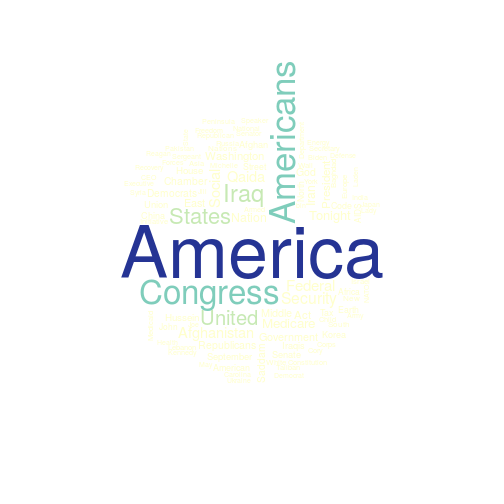

```r
dtm = with(subset(sotu.tokens, pos1=="M"),
           dtm.create(aid, lemma))
dtm.wordcloud(dtm)
```

### Corpus Statistics

```r
stats = term.statistics(dtm)
stats= arrange(stats, -termfreq)
head(stats)
```

| term | characters | number | nonalpha | termfreq | docfreq | reldocfreq | tfidf |
| --- | --- | --- | --- | --- | --- | --- | --- |
| America | 7 | FALSE | FALSE | 409 | 346 | 0.3940774 | 0.6883991 |
| Americans | 9 | FALSE | FALSE | 179 | 158 | 0.1799544 | 1.4280099 |
| Congress | 8 | FALSE | FALSE | 168 | 149 | 0.1697039 | 1.1398894 |
| Iraq | 4 | FALSE | FALSE | 109 | 65 | 0.0740319 | 1.4157528 |
| States | 6 | FALSE | FALSE | 99 | 89 | 0.1013667 | 0.9573274 |
| United | 6 | FALSE | FALSE | 88 | 82 | 0.0933941 | 0.7817946 |

## Comparing Corpora

Compare speakers, media, periods, …

### Obama's speeches

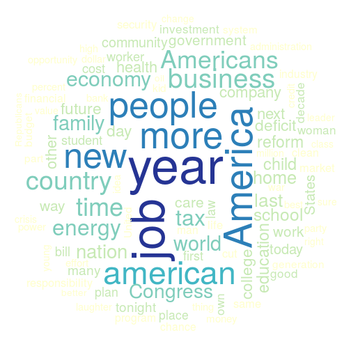

```r
library(corpustools)
data(sotu)
obama = sotu.meta$id[sotu.meta$headline == "Barack Obama"]
dtm_o = with(subset(sotu.tokens, aid %in% obama & pos1 %in% c("N", "A", "M")),
           dtm.create(aid, lemma))
dtm.wordcloud(dtm_o)
```

### Comparing Corpora

```r
dtm_b = with(subset(sotu.tokens, !(aid %in% obama) & pos1 %in% c("N", "A", "M")),
           dtm.create(aid, lemma))
cmp  = corpora.compare(dtm_o, dtm_b)
cmp = arrange(cmp, -chi)
head(cmp)
```

| term | termfreq.x | termfreq.y | termfreq | relfreq.x | relfreq.y | over | chi |
| --- | --- | --- | --- | --- | --- | --- | --- |
| job | 200 | 56 | 256 | 0.0195351 | 0.0051090 | 3.3614321 | 92.34135 |
| terrorist | 13 | 103 | 116 | 0.0012698 | 0.0093970 | 0.2183120 | 64.24944 |
| freedom | 8 | 79 | 87 | 0.0007814 | 0.0072074 | 0.2170491 | 53.48220 |
| Iraq | 15 | 94 | 109 | 0.0014651 | 0.0085759 | 0.2574317 | 52.32461 |
| terror | 0 | 55 | 55 | 0.0000000 | 0.0050178 | 0.1661740 | 51.50577 |
| business | 109 | 31 | 140 | 0.0106466 | 0.0028282 | 3.0423131 | 49.32315 |

### Contrast plots

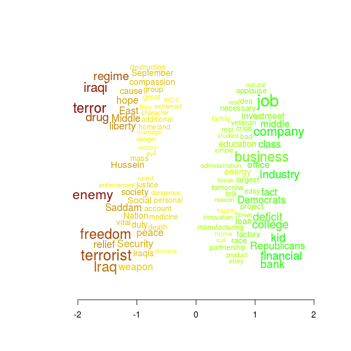

```r
with(utils::head(cmp, 100),
plotWords(x=log(over), words = term, wordfreq = chi, random.y = T))
```

### Comparing multiple corpora

- Requires subcorpus variable
- Align meta to dtm

```r
rownames(dtm_o)[1:3 ]
```

```
[1] "111541965" "111541995" "111542001"
```

```r
meta = sotu.meta[match(rownames(dtm_o), sotu.meta$id), ]
meta$year = format(meta$date, "%Y")
head(meta)
```

| id | medium | headline | date | year |
| --- | --- | --- | --- | --- |
| 111541965 | Speeches | Barack Obama | 2013-02-12 | 2013 |
| 111541995 | Speeches | Barack Obama | 2013-02-12 | 2013 |
| 111542001 | Speeches | Barack Obama | 2013-02-12 | 2013 |
| 111542006 | Speeches | Barack Obama | 2013-02-12 | 2013 |
| 111542013 | Speeches | Barack Obama | 2013-02-12 | 2013 |
| 111542018 | Speeches | Barack Obama | 2013-02-12 | 2013 |

### Comparing multiple corpora

```r
d = corpora.compare.list(dtm_o, as.character(meta$year), return.df=T, .progress="none")
d = arrange(d,-chi)
head(d)
```

| corpus | term | termfreq.x | termfreq.y | termfreq | relfreq.x | relfreq.y | over | chi |
| --- | --- | --- | --- | --- | --- | --- | --- | --- |
| 2009 | plan | 21 | 18 | 39 | 0.0145429 | 0.0020469 | 5.101313 | 51.03811 |
| 2014 | Cory | 9 | 0 | 9 | 0.0049724 | 0.0000000 | 5.972376 | 41.94405 |
| 2013 | reduction | 7 | 0 | 7 | 0.0039909 | 0.0000000 | 4.990878 | 33.88177 |
| 2012 | unit | 7 | 0 | 7 | 0.0039326 | 0.0000000 | 4.932584 | 33.28456 |
| 2009 | recovery | 11 | 7 | 18 | 0.0076177 | 0.0007960 | 4.798297 | 32.88778 |
| 2009 | lending | 6 | 1 | 7 | 0.0041551 | 0.0001137 | 4.628769 | 29.64959 |

## Topic Modeling

### Topic Modeling

- Cluster words and documents
- Comparable to factor analysis of DTM
- Latent Dirichlet Allocation
  - Generative model
  - Writer picks mix of topics
  - Each topic is mix of words
  - Writer picks words from topics
- Many advanced versions exist
  - Structural topic models
  - Hierarchical topic models

### Topic Modeling in R

```r
library(corpustools)
set.seed(123)
m = lda.fit(dtm_o, K = 5, alpha = .1)
kable(terms(m, 10))
```

| Topic 1 | Topic 2 | Topic 3 | Topic 4 | Topic 5 |
| --- | --- | --- | --- | --- |
| people | America | job | job | year |
| country | world | school | new | tax |
| time | people | education | energy | more |
| future | security | college | year | family |
| government | new | child | business | deficit |
| american | american | student | America | health |
| America | country | kid | more | care |
| Americans | war | America | company | Americans |
| day | year | more | american | cost |
| nation | troops | high | worker | Congress |

### Visualizing LDA

```r
library(LDAvis)
json = ldavis_json(m, dtm_o)
serVis(json)
```

### How many topics?

- Inspect result
  - Mixed topics? increase K
  - Very similar topics? decrease K
- Perplexity measure for different K
  - Scree plot
- Jacobi, Van Atteveldt & Welbers (2016)
- (there will always be junk topics)

### Perplexity

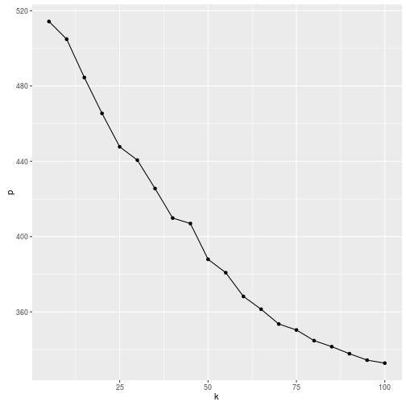

```r
p = readRDS("perplex.rds")
p = aggregate(p["p"], p["k"], mean)
library(ggplot2)
ggplot(p, aes(x=k, y=p, )) + geom_line()  +geom_point()
```

### Analyzing LDA results

```r
tpd = topics.per.document(m)
tpd = merge(sotu.meta, tpd)
head(tpd)
```

| id | medium | headline | date | X1 | X2 | X3 | X4 | X5 |
| --- | --- | --- | --- | --- | --- | --- | --- | --- |
| 111541965 | Speeches | Barack Obama | 2013-02-12 | 0.8133333 | 0.0133333 | 0.0133333 | 0.1466667 | 0.0133333 |
| 111541995 | Speeches | Barack Obama | 2013-02-12 | 0.0933333 | 0.0044444 | 0.4488889 | 0.4488889 | 0.0044444 |
| 111542001 | Speeches | Barack Obama | 2013-02-12 | 0.0400000 | 0.0036364 | 0.6581818 | 0.0400000 | 0.2581818 |
| 111542006 | Speeches | Barack Obama | 2013-02-12 | 0.4628571 | 0.0057143 | 0.5200000 | 0.0057143 | 0.0057143 |
| 111542013 | Speeches | Barack Obama | 2013-02-12 | 0.2897959 | 0.3306122 | 0.2897959 | 0.0857143 | 0.0040816 |
| 111542018 | Speeches | Barack Obama | 2013-02-12 | 0.0046512 | 0.0976744 | 0.4232558 | 0.4697674 | 0.0046512 |

## Workshop Overview

Session 1

- Organizing & Transforming data
- Accessing APIs from R

Session 2

- Corpus Analysis
- *Network Analysis*

### (Social) Network analysis in R

- Package `igraph`
- Edges and Vertices
- Set attrbiutes with `E(g)$label`, etc
- Functions for clustering, centrality, plotting, etc.
- Exporting/Importing to/from gephi, pajek, UCInet etc.

### Semantic Network Analysis

- Co-occurrence of concepts as semantic relation
- Possibly limited to word-window
- Useful to limit to e.g. nouns or noun+verbs
- See e.g. Doerfel/Barnett 1999, Diesner 2013, Leydesdorff/Welbers 2011

### Semantic Network Analysis in R

- Package `semnet`
  - `github.com/kasperwelbers/semnet`
- Input dtm or token list, output graph

```r
library(semnet)
g = coOccurenceNetwork(dtm)

g = windowedCoOccurenceNetwork(location, term, context)
```

### Backbone extraction

- Semantic networks are very large
- Backbone extraction extracts most important edges

```r
g_backbone = getBackboneNetwork(g, alpha=0.01, max.vertices=100)
```

### Exporting graphs

- Export to e.g. UCInet, gephi
- More visualization, metrics

```r
write.graph(g, filename, format)

library(rgexf)
gefx = igraph.to.gexf(g)
print(gefx, file="..")
```

### Semnet for Sentiment Analysis

- Sentiment around specific terms
- Windowed co-occurrence of sentiment terms, concepts
- More specific approach using syntax: Van Atteveldt et al., forthcoming

### Hands-on session 2

Hand-outs:

- Corpus analysis
- Comparing Corpora
- Topic Modeling
- S/SN from Twitter

## Thank You!

What you have learned:

- Data management with R
- Corpus Analysis
- Topic Modeling
- Social / Semantic Network Analysis

Go out and code!